# Upper Cook Inlet Exclusive Economic Zone Harvest

Adam Reimer

2022-12-29

# UCI EEZ Harvest Estimates

## Methods

The Division of Sport Fish conducts the mail-based Statewide Harvest Survey (SWHS) to estimate sport fishing annual effort (angler-days), harvest (fish kept), and total catch (fish kept plus fish released). Effort, harvest, and catch estimates are available by geographic area, but are not specifically available for the EEZ. The closest available geographic area is Upper Cook Inlet salt waters (marine waters in Cook Inlet North of a line between Bluff Point and Chinitna Point), which shares a southern boundary with the Upper Cook Inlet EEZ but contains both State and Federal waters in Upper Cook Inlet. Harvest and catch estimates are available for species commonly targeted by sport anglers and are available stratified into categories such as boat/shore and charter/non-charter.

In addition, all saltwater sport fishing guide operators are required to maintain an ADF&G-issued logbook of their clients’ catch. The Division of Sport Fish conducts a program to issue Saltwater Charter Logbooks, which provides a census of effort, harvest, and catch for guided anglers. Charter captains record the statistical area where the majority of their sport effort, catch and harvest occurred. Separate areas are recorded for groundfish fishing and for salmon fishing. Prior to 2015 groundfish statistical areas were used to document geographic area for both salmon and groundfish fishing, while salmon statistical areas were used for salmon fishing beginning in 2015. Groundfish areas delineate state and federal waters well with respect to distance form shore, but include marine waters in both Upper and Lower Cook Inlet. Salmon statistical areas delineate Upper and Lower Cook Inlet well but span both federal and state waters with respect to distance from shore. Therefore, while logbook data can be used to provide a rough estimate of the proportion of the guided harvest that occurred in the EEZ for each species and year it is not a clear distinction and any inherit bias may vary before and after 2014.

$$\begin{equation}
p^G_{y}~=~\frac{\sum_g^{\in UCI^G_{fed}} L_{yg}}{\sum_g^{\in UCI^G}
L_{yg}}
\end{equation}$$

where $L_{yg}$ is the reported harvest by charter operators in year $y$ and in statistical areas $g$.

Salmon statistical areas 221000, 221010, 221020, 221030, 221040, 221050, 221060, 221070, and 221080 were considered part of Upper Cook Inlet (defined as set $UCI^S$ below) while areas 221000, and 221030 were considered Federal waters (defined as set $UCI^{Sfed}$ below). The estimate of the annual proportion of harvest occurred in in the UCI EEZ for years 2015 and later p^S_{y} is:

$$\begin{equation}
p^S_{y}~=~\frac{\sum_s^{\in UCI^S_{fed}} L_{ys}}{\sum_s^{\in UCI^S}
L_{ys}}
\end{equation}$$

where $L_{ys}$ is the reported harvest by charter operators in year $y$ and in statistical areas $s$.

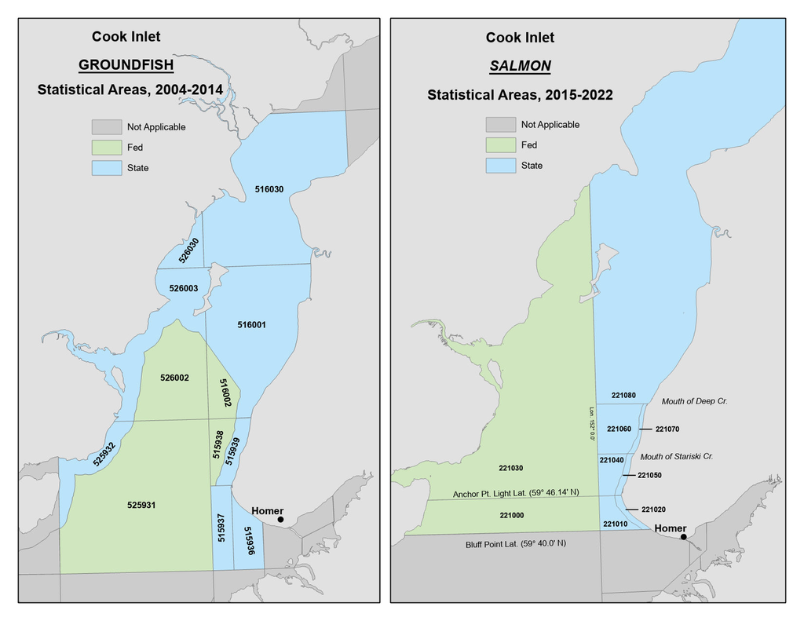

Herein we use the product of estimates of the proportion of salmon harvest that occur in federal waters in the Upper Cook Inlet EEZ from the Charter logbook program ($p^G_{y}$ or $p^S_{y}$) and SWHS estimates for king, coho and sockeye salmon harvest from boats in Upper Cook Inlet each year since 2004 $S^{boat}_y$ to estiamte harvest with the Upper Cook Inlet EEZ. Thus, UCI harvest estimates within the EEZ are:

$$\begin{equation}
H^{federal}_{y}~=~p^X_{y}*S^{boat}_y
\end{equation}$$

where $p^X_{y}$ is $p^G_{y}$ prior to 2015 and $p^S_{y}$ thereafter.

UCI harvest estimates in state waters are:

$$\begin{equation}
H^{state}_{y}~=~(1 - p^X_{y})*S^{boat}_y+S^{shore}_y
\end{equation}$$

This approach assumes that guided and unguided fisheries have equal proportions of harvest in federal waters.

## Results

The change to salmon statistical areas appears to have had a significant impact on our estimate of the proportion of harvest within federal waters for charter logbook data. After salmon statistical areas were implemented in 2015 the percentage of boats attributed to federal waters fell markedly as did the percentage of harvest for coho, king and sockeye salmon.

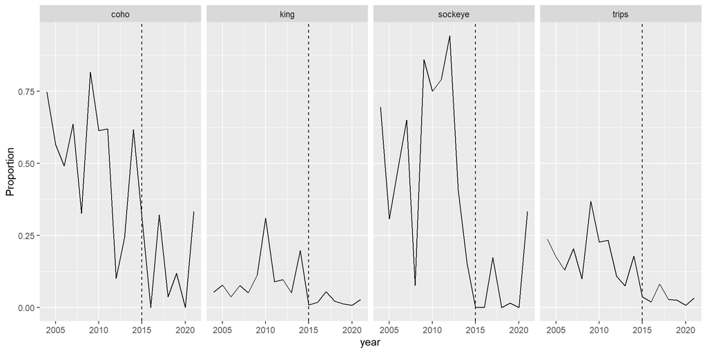

Figure 2.- Proportion of Charter logbook trips and harvest reported in federal waters, 2004-2021.

Table 1.- Estimated Harvest within the Upper Cook Inlet EEZ, 2004–2021.

| year | coho | king | sockeye | trips |
| --- | --- | --- | --- | --- |
| 2004 | 2993 | 293 | 257 | NA |
| 2005 | 1825 | 374 | 380 | NA |
| 2006 | 1469 | 221 | 767 | NA |
| 2007 | 1298 | 372 | 624 | NA |
| 2008 | 516 | 138 | 168 | NA |
| 2009 | 1556 | 188 | 1203 | NA |
| 2010 | 1394 | 718 | 1217 | NA |
| 2011 | 1376 | 273 | 1411 | NA |
| 2012 | 222 | 137 | 1614 | NA |
| 2013 | 1043 | 132 | 909 | NA |
| 2014 | 1482 | 504 | 328 | NA |
| 2015 | 1628 | 41 | 0 | NA |
| 2016 | 0 | 67 | 0 | NA |
| 2017 | 1122 | 215 | 362 | NA |
| 2018 | 83 | 99 | 0 | NA |
| 2019 | 209 | 41 | 44 | NA |
| 2020 | 0 | 21 | 0 | NA |
| 2021 | 341 | 63 | 572 | NA |

## Comparison to previous estimates

Previous estimates or salmon harvest in the Upper Cook Inlet EEZ used the same methodology but used charter logbook data from a larger geographic area. Figure 3 shows the statistical areas and the categorization as federal and state waters used in previous estimates.

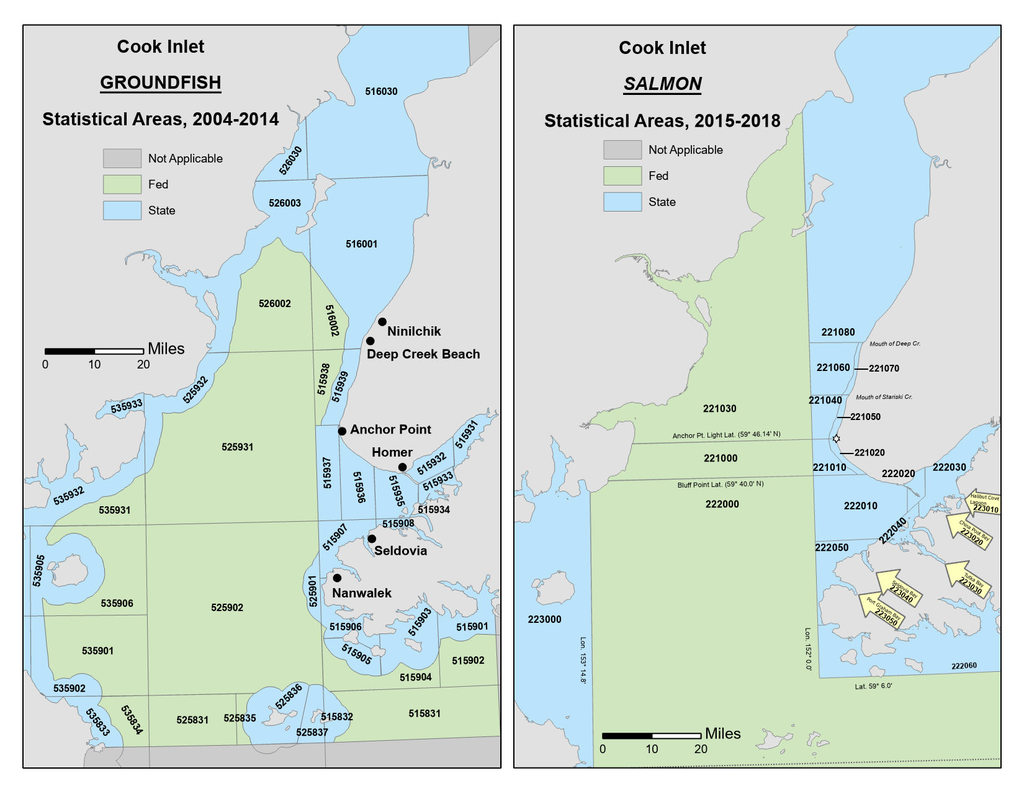

Estimates of the percentage of effort and harvest in federal waters follow the same general trend when all of Cook Inlet is used to generate the estimates.

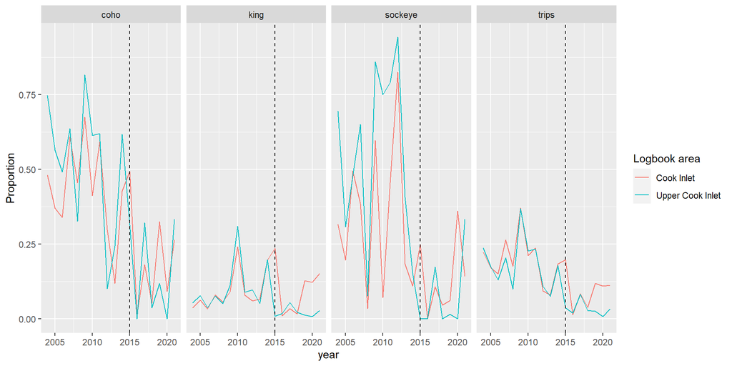

Figure 4.- Proportion of Charter logbook harvest reported in federal waters, 2004-2021.

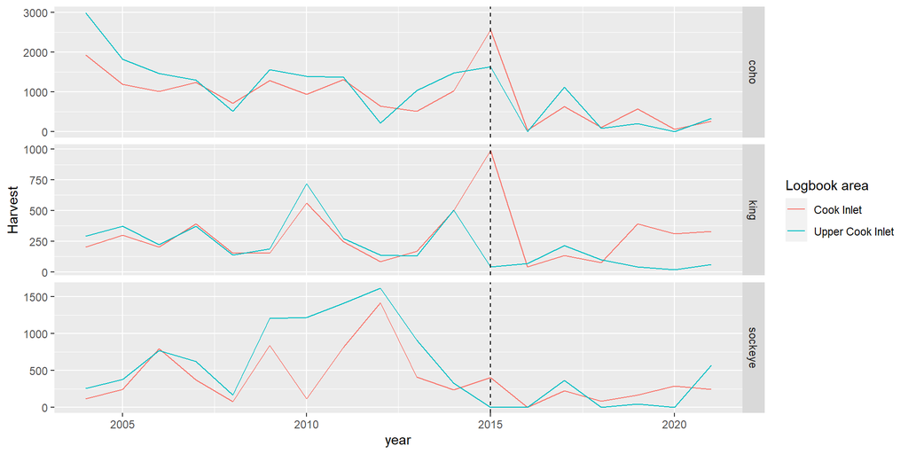